[O’Hara on GitHub](https://github.com/oharac)

# Sensitivity analysis: Functional Entity grouping traits

Compiled on Tue Oct 14 22:58:36 2025 by ohara

```r
knitr::opts_chunk$set(echo = TRUE,
                      # message = FALSE,
                      warning = FALSE,
                      fig.height = 4, fig.width = 7)

library(terra)
library(oharac)
library(data.table)
library(tidyverse)
library(here)
source(here('common_fxns.R'))
```

# 1 Summary

Sensitivity analysis to determine how drastically scores change with different values of functional traits.

1. Identify a set of sample cells for analysis (let’s go with 100,000).
   - For each cell, identify the species found in that location.
   - Determine spp richness, functional richness and vulnerability. Spp richness will not change, but others probably will.
   - Determine FE-weighted mean impacts. Spp-weighted will not change, but FE-weighted may change depending on how FV changes.
2. For each trait (max body length, trophic level, adult mobility, position in water column), for each sample cell:
   - Shuffle all existing trait values, sampling with replacement bootstrap-style - this keeps distribution largely identical but allows some variation

*NOTE*: SHUFFLE TRAIT VALUES ONLY THOSE FOUND WITHIN CELL, OR SHUFFLE ACROSS ALL SPECIES IN SPECIES SET?

```
* Calculate functional richness and vulnerability with randomized trait set.
* Calculate impacts for each stressor based on new functional vulnerability, and cumulative impact.
```

3. Repeat step 2 many many times, Monte Carlo style.
   - For each pixel, calculate distribution (mean, std dev, 95% CI):
     - Distribution of FR and FV around “true” value (“true” meaning scores based on determined trait set).
     - Distribution of impacts around “true” value
     - Distribution of CHI around “true” value
4. Examine these distributions around the globe
   - Map summary stats; interpolate to see any global gradients vs. random?
   - Plot summary stats vs. spp richness and/or latitude

# 2 Methods

## 2.1 Identify cells

Gather maps of the “true” state of species richness, functional richness, cumulative impacts, etc.

```r
chi_r <- rast(here('_output/cumulative_impact_maps/chi_funct_entity.tif')) %>%
  setNames('chi')
sr_r  <- rast(here('_output/nspp_maps/species_richness.tif')) %>%
  setNames('nspp')
fr_r  <- rast(here('_output/nspp_maps/funct_entity_richness.tif')) %>%
  setNames('n_fe')
fv_r  <- rast(here('_output/nspp_maps/mean_funct_vulnerability.tif')) %>%
  setNames('fv')
cell_id_r <- chi_r %>% setValues(1:ncell(.)) %>% setNames('cell_id')

cell_id_df <- as.data.frame(c(chi_r, sr_r, fr_r, fv_r, cell_id_r),
                         xy = TRUE) %>%
  filter(!is.na(chi))
```

### 2.1.1 Select sample of cells

Choose 100,000 cells randomly and filter our full cell data.frame down to just these cells.

```r
set.seed(42)
n_cells <- 100000
cell_sample_df <- cell_id_df %>%
  sample_n(n_cells)

cell_id_vec <- cell_sample_df$cell_id %>% sort()

rm('cell_id_df') ### don't need this one any more
```

## 2.2 Gather other information

Gather species information including traits and vulnerability scores.

```r
spp_info <- assemble_spp_info_df()
spp_traits_df <- spp_info %>%
  select(species, mob, trp, len, wcol) %>%
  distinct()
```

Gather uniform-exposure stressor information.

```r
str_vuln_lookup <- read_csv(here('_raw/stressor_vulnerability_lookup.csv'), show_col_types = FALSE)
strs <- str_vuln_lookup$stressor
strs_unif <- strs[!str_detect(strs, 'sst_rise|biomass_removal|bycatch')]

str_fs <- list.files(here('_data/stressors_mol'),
                     full.names = TRUE)

str_rast <- rast(str_fs) %>%
  setNames(basename(str_fs) %>% str_remove('_[0-9]{4}.+'))
str_cell_df <- c(str_rast, cell_id_r) %>%
  as.data.frame(xy = TRUE) %>%
  filter(cell_id %in% cell_id_vec) %>%
  mutate(across(everything(), ~ifelse(is.na(.x), 0, .x)))

imp_fs <- list.files(here_anx('_output/impact_maps/impact_maps_funct_entity'),
                     full.names = TRUE)
imp_fs <- imp_fs[str_detect(imp_fs, 'mean.tif')]

imp_rast <- rast(imp_fs) %>%
  setNames(basename(imp_fs) %>% str_remove_all('impact_fe_|_x_.+|_mean.tif'))

imp_cell_df <- c(imp_rast, cell_id_r) %>%
  as.data.frame(xy = TRUE) %>%
  filter(cell_id %in% cell_id_vec) %>%
  mutate(across(everything(), ~ifelse(is.na(.x), 0, .x)))
```

### 2.2.1 Map sample locations

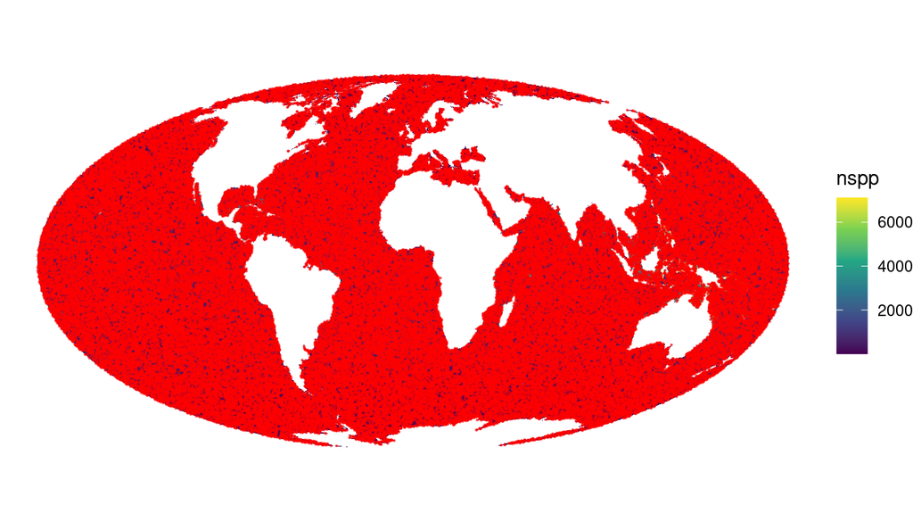

```r
sr_df <- sr_r %>% as.data.frame(xy = TRUE)
ggplot() +
  geom_raster(data = sr_df, aes(x, y, fill = nspp)) +
  geom_point(data = cell_sample_df, aes(x, y), color = 'red', size = 0.1, alpha = .5) +
  coord_sf() +
  scale_fill_viridis_c() +
  theme_void()
```

## 2.3 Gather species in these cells

Read in each species rangemap file and filter down to just those cells in our sample.

```r
get_spp_cells <- function(spp_name, cell_id_vec, spp_info) {
  ### f <- spp_map_fs[1]
  f <- spp_info %>%
    filter(species == spp_name) %>%
    .$map_f %>% unique()
  data_src <- spp_info %>%
    filter(species == spp_name) %>%
    .$src %>% unique()

  tmp_df <- read_csv(f, show_col_types = FALSE)

  if(data_src == 'iucn') {
    tmp_df <- tmp_df %>%
      filter(presence != 5)
  } else {
    tmp_df <- tmp_df %>%
      filter(prob >= .5)
  }
  ### get cells and strip down to just those in sample; return as dataframe
  spp_cells <- tmp_df$cell_id
  spp_cells <- spp_cells[spp_cells %in% cell_id_vec]
  if(length(spp_cells) == 0) spp_cells <- -1

  ### return result
  return(data.frame(species = spp_name, cell_id = spp_cells))
}
```

Pulling all spp and filtering down to just the sample cells will be slow regardless of how many sample cells - because *all* species maps have to be pulled.

```r
spp_names_f <- here_anx('sens_analysis/spp_name_to_id.csv')
spp_cells_f <- here_anx('sens_analysis/spp_cells_to_id.csv')

if(any(!file.exists(spp_names_f, spp_cells_f))) {
  spp_name_vec <- spp_info$species %>% unique()

  # tictoc::tic()
  message('Getting species presence for ', length(spp_name_vec),
          ' species across ', length(cell_id_vec), ' sample cells...')
  spp_cells_list <- parallel::mclapply(spp_name_vec,
                                       FUN = get_spp_cells,
                                       cell_id_vec = cell_id_vec,
                                       spp_info = spp_info,
                                       mc.cores = 16)
  # tictoc::toc()

  spp_cells_sample_df <- spp_cells_list %>%
    bind_rows() %>%
    filter(cell_id != -1) %>%
    mutate(species = factor(species),
           spp_id = as.integer(species)) %>%
    distinct()

  spp_names_out <- spp_cells_sample_df %>%
    select(species, spp_id) %>%
    distinct()
  spp_cells_out <- spp_cells_sample_df %>%
    select(cell_id, spp_id) %>%
    distinct()
  write_csv(spp_names_out, spp_names_f)
  write_csv(spp_cells_out, spp_cells_f)
}

spp_cells_sample_df <- read_csv(spp_names_f, show_col_types = FALSE) %>%
  left_join(read_csv(spp_cells_f, show_col_types = FALSE), by = 'spp_id') %>%
  select(-spp_id)
```

## 2.4 Shuffle traits and calc cell FD values

```r
shuffle_trait <- function(df, trait, traits_df = spp_traits_df) {

  df2 <- df %>%
    oharac::dt_join(traits_df, by = 'species', type = 'left') %>%
    rename(tmp := all_of(trait)) %>%
    group_by(cell_id) %>%
    mutate(tmp = sample(tmp, size = n(), replace = TRUE)) %>%
    ungroup() %>%
    rename(!!trait := tmp)

  spp_fe_cells <- df2 %>%
    assign_fe()

  return(spp_fe_cells)
}

assign_fe <- function(df) {
  ### summarize FEs across all spp in the set
  tmp <- df %>%
    unite(col = trait, mob, trp, len, wcol) %>%
    group_by(trait) %>%
    summarize(spp_in_fe = n_distinct(species)) %>%
    arrange(-spp_in_fe) %>%
    mutate(fe_id = 1:n()) %>%
    separate(col = trait, into = c('mob', 'trp', 'len', 'wcol'))

  spp_fes_out <- df %>%
    left_join(tmp, by = c('mob', 'trp', 'len', 'wcol')) %>%
    select(cell_id, species, fe_id)

  return(spp_fes_out)
}

calc_fd_metrics <- function(df) {
  tmp <- df %>%
    as.data.table() %>%
    .[ , .(n_spp_fe = length(unique(species)),
           fv_fe = calc_fe(length(unique(species)))),
       by = .(cell_id, fe_id)] %>%
    .[ , .(n_fe = length(unique(fe_id)),
           fv = mean(fv_fe)),
       by = .(cell_id)]
  return(tmp)
}

summarize_fd_stats <- function(df, truth_df = cell_sample_df) {
  message('Summarizing functional diversity stats...')
  fd_result_summary <- df %>%
    as.data.table() %>%
    .[ , .(n_fe_mean = mean(n_fe),
              n_fe_95lo = quantile(n_fe, .025),
              n_fe_95hi = quantile(n_fe, .975),
              n_fe_sdev = sd(n_fe),
              fv_mean = mean(fv),
              fv_95lo = quantile(fv, .025),
              fv_95hi = quantile(fv, .975),
              fv_sdev = sd(fv)),
       by = cell_id]

  fd_results_check <- fd_result_summary %>%
    left_join(truth_df, by = 'cell_id') %>%
    mutate(diff_n_fe = n_fe_mean - n_fe,
           diff_fv   = fv_mean - fv) %>%
    select(-x, -y)
    return(fd_results_check)
}

drop_missing_iters <- function(tmp_fs) {
  result_df <- parallel::mclapply(tmp_fs, fread, mc.cores = 20) %>%
    setNames(tmp_fs) %>%
    rbindlist(idcol = 'f')
  nrows <- result_df %>%
    as.data.table() %>%
    .[ , .(n = length(cell_id)), by = f]
  print(nrows %>% filter(n < n_cells))

  iters_problem <- nrows$f[nrows$n < n_cells]
  unlink(iters_problem)
}

bind_tmp_fs <- function(tmp_fs, n) {
  message('Checking temp files and binding...')
  ### error checks... any files missing?
  if(length(tmp_fs) < n) stop('Missing some files!')
  ### error checks... any files with dropped cells?
  result_df <- parallel::mclapply(tmp_fs, fread, mc.cores = 20) %>%
    setNames(tmp_fs) %>%
    rbindlist(idcol = 'f')
  nrows <- result_df %>%
    as.data.table() %>%
    .[ , .(n = length(cell_id)), by = f]
  if(!all(nrows$n == n_cells)) stop('Missing some iterations!')
  ### iters_problem <- nrows$f[nrows$n < n_cells]
  ### unlink(iters_problem)
  return(result_df %>% select(-f))
}
```

## 2.5 Shuffle traits and calc functional diversity metrics

Shuffle within cells, rather than across entire species set. Write out as summary data frame; if data frame exists, don’t re-run it all!

```r
n_sims <- 1000

trait_vec <- c('len', 'mob', 'trp', 'wcol')
out_fstem <- here_anx('sens_analysis/funct_div_summary/fd_summary_shuffle_%s.csv')

for(i in seq_along(trait_vec)) {
  # i <- 1
  tr <- trait_vec[i]
  out_f <- sprintf(out_fstem, tr)

  if(!file.exists(out_f)) {
    message('Shuffling trait ', tr, ' and summarizing to ', basename(out_f), '...')

    tmp_out_fstem <- here_anx('sens_analysis/funct_div_summary/tmp',
                              'tmp_fd_summary_shuffle_%s_%s.csv')

    zxcv <- parallel::mclapply(
      1:n_sims, mc.cores = 10,
      FUN = function(j) {
        # j <- 1
        tmp_out_f <- sprintf(tmp_out_fstem, tr, j)
        if(file.exists(tmp_out_f)) return(NULL)

        ### set a different determinate seed each iteration/trait combo
        ### this ensures repeatability if needing to re-run any iteration/trait set
        rnd_seed <- (i + n_sims * j) * 42
        set.seed(rnd_seed)
        if(j %% 20 == 0 | runif(1) < .1) {
          message('Random seed for ', tr, ' iter ', j, ' = ', rnd_seed)
        }

        spp_fe_cells <- spp_cells_sample_df %>%
          shuffle_trait(trait = tr)

        fd_metrics <- spp_fe_cells %>%
          calc_fd_metrics()

        write_csv(fd_metrics, tmp_out_f)
      }
    )

    tmp_fs <- list.files(dirname(tmp_out_fstem),
                         pattern = sprintf('tmp_fd_summary_shuffle_%s', tr),
                         full.names = TRUE)

    fd_result_df <- bind_tmp_fs(tmp_fs, n = n_sims) ### includes error checks

    fd_result_summary <- fd_result_df %>%
      summarize_fd_stats() %>%
      ### round out ludicrous precision
      mutate(across(where(is.numeric), ~round(.x, 6)))

    write_csv(fd_result_summary, out_f)
    unlink(tmp_fs)
  }
}
```

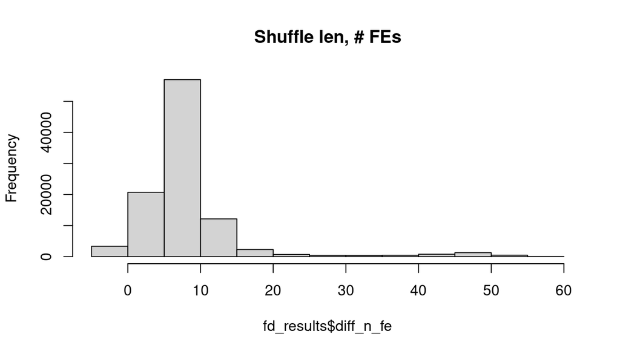

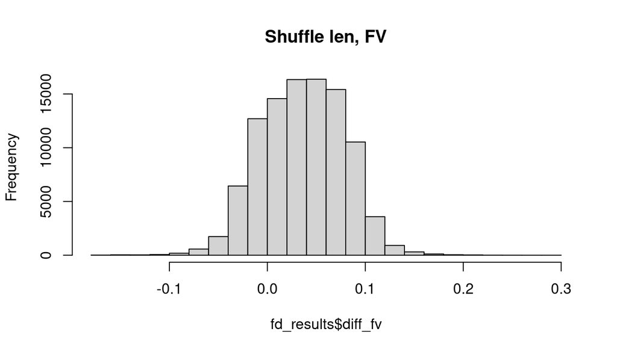

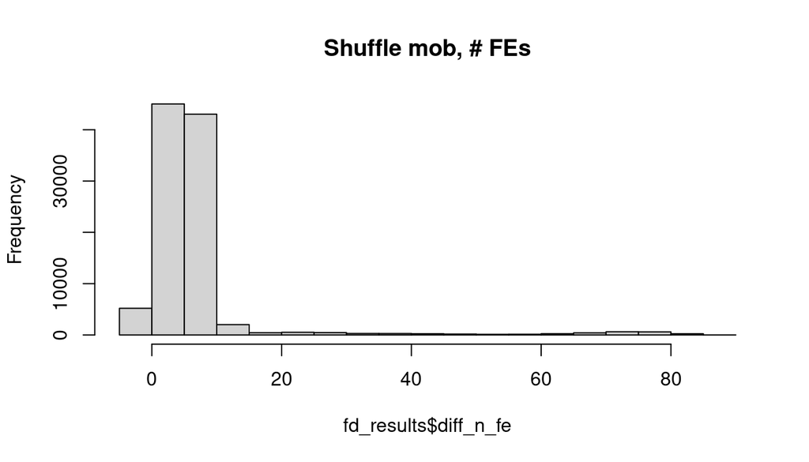

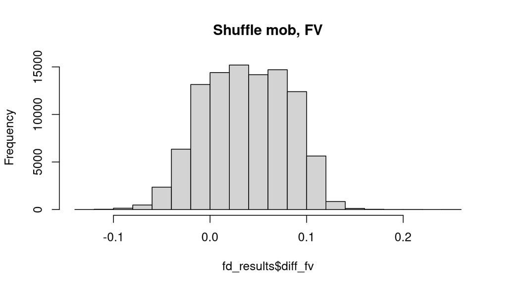

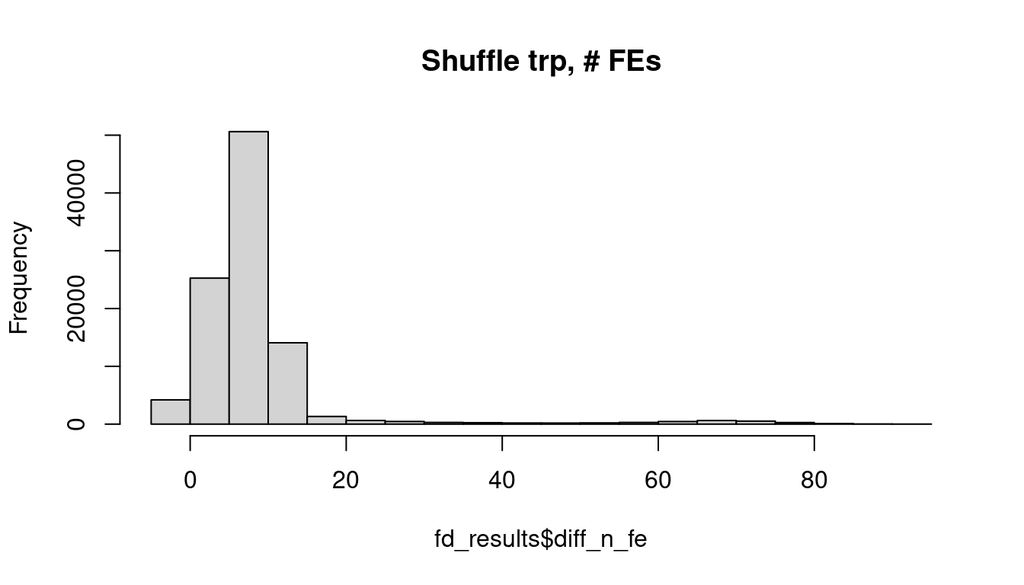

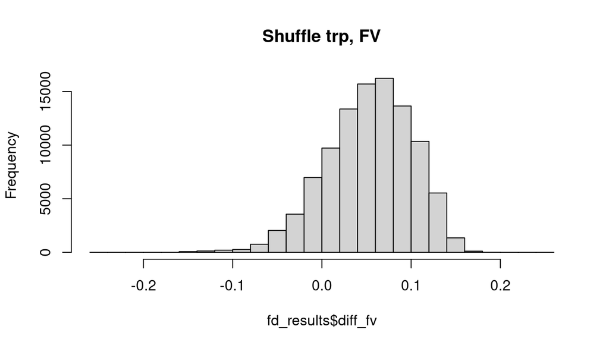

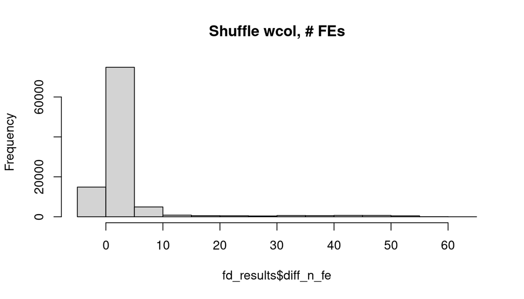

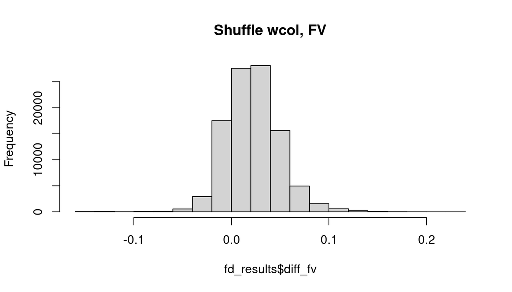

```r
fd_results_fs <- sprintf(out_fstem, trait_vec) %>%
  setNames(trait_vec)

### unlink(fd_results_fs)
for(tr in trait_vec) {
  fd_results <- read_csv(fd_results_fs[tr], show_col_types = FALSE)
  hist(fd_results$diff_n_fe, main = sprintf('Shuffle %s, # FEs', tr))
  hist(fd_results$diff_fv,   main = sprintf('Shuffle %s, FV', tr))
}
```

When randomizing any of the traits, functional richness and vulnerability both seem to increase on average. Logically, if (for the same number of species) functional richness increases, then functional vulnerability should probably increase as well, since number of spp per FE would on average decrease.

## 2.6 Shuffle traits and calc uniform exposure stressor vuln and impacts

Shuffle within cells, rather than across entire species set. Write out as summary data frame; if data frame exists, don’t re-run it all!

Note: Because these are scalar multipliers, we can calculate the distribution summary stats of vulnerability across multiple iterations and simply multiply by the stressor intensity, rather than multiplying by stressor intensity for each iteration.

Because of the processing demands, let’s just do 200 sims of each of these. This should still give us a reasonable estimate of 95% confidence intervals.

```r
get_spp_vuln_df <- function(str, str_vuln = str_vuln_lookup, spp = spp_info) {
  vuln_name <- str_vuln %>%
    filter(stressor == str) %>%
    .$vulnerability
  spp_vuln_df <- spp %>%
    filter(stressor == vuln_name) %>%
    select(species, v_score, vuln = stressor) %>%
    distinct()
  return(spp_vuln_df)
}

calc_cell_vuln <- function(spp_fe_cells, spp_vuln_df) {
  spp_fe_vuln_cells <- spp_fe_cells %>%
    oharac::dt_join(spp_vuln_df, by = 'species', type = 'left') %>%
    as.data.table() %>%
    .[ , .(cell_vuln = mean(v_score),
           fv = calc_fe(n_distinct(species))),
       by = .(cell_id, fe_id)] %>%
    .[ , .(cell_vuln = sum(cell_vuln * fv) / sum(fv)),
       by = cell_id]

  return(spp_fe_vuln_cells)
}

calc_mean_impact <- function(df, str, int_cells = str_cell_df, imp_cells = imp_cell_df) {
  true_impact_df <- imp_cells %>%
    select(cell_id, impact := all_of(str))
  str_intensity_df <- int_cells %>%
    select(cell_id, intensity := all_of(str))
  str_impact_result_df <- df %>%
    as.data.table() %>%
    .[ , .(vuln_mean = mean(cell_vuln),
           vuln_sdev = sd(cell_vuln),
           vuln_95lo = quantile(cell_vuln, .025),
           vuln_95hi = quantile(cell_vuln, .975)),
       by = cell_id] %>%
    left_join(str_intensity_df, by = 'cell_id') %>%
    mutate(imp_mean = vuln_mean * intensity,
           imp_sdev = vuln_sdev * intensity,
           imp_95lo = vuln_95lo * intensity,
           imp_95hi = vuln_95hi * intensity) %>%
    left_join(true_impact_df, by = 'cell_id') %>%
    mutate(diff_imp_mean = impact - imp_mean) %>%
    ### round out ludicrous precision
    mutate(across(where(is.numeric), ~round(.x, 6))) %>%
    select(-intensity)
}
```

```r
out_fstem <- here_anx('sens_analysis/impact_summary/impact_shuffle_%s_%s.csv')
n_sims_imp <- 200

### Loop over traits to be shuffled
for(i in seq_along(trait_vec)) {
  # i <- 1
  tr <- trait_vec[i]

  ### loop over stressors to be calculated
  for(j in seq_along(strs_unif)) {
    # j <- 10
    str <- strs_unif[j]

    out_f <- sprintf(out_fstem, tr, str)

    if(!file.exists(out_f)) {
      message('Shuffling trait ', tr, ' for stressor ', str,
              ' and summarizing to ', basename(out_f), '...')

      tmp_out_fstem <- here_anx('sens_analysis/impact_summary/tmp',
                                'tmp_unif_exp_summary_shuffle_%s_%s_%s.csv')

      ### load vulnerability df for this loop (stressor)
      spp_vuln_df <- get_spp_vuln_df(str = str)

      ### Loop over simulations
      zxcv <- parallel::mclapply(
        1:n_sims_imp, mc.cores = 10,
        FUN = function(k) {
          # k <- 200
          tmp_out_f <- sprintf(tmp_out_fstem, tr, str, k)
          if(file.exists(tmp_out_f)) return('ok')

          ### set a different determinate seed each iteration/trait combo
          rnd_seed <- (i + n_sims_imp * k) * 42
          set.seed(rnd_seed)
          if(k %% 20 == 0 | runif(1) < .1) {
            message('Random seed for ', tr, ', str ', str,
                    ': iter ', k, ' = ', rnd_seed)
          }

          ### attach stressor vulnerability and summarize to mean per cell
          spp_fe_cells <- spp_cells_sample_df %>%
            shuffle_trait(trait = tr)
          system.time({
            spp_fe_vuln_cells <- calc_cell_vuln(spp_fe_cells, spp_vuln_df)
          })

          write_csv(spp_fe_vuln_cells, tmp_out_f)
          return(paste('Created', basename(tmp_out_f)))
        }
      )### end of sim iteration loop

      tmp_fs <- list.files(dirname(tmp_out_fstem),
                           pattern = sprintf('tmp_unif_exp_summary_shuffle_%s_%s', tr, str),
                           full.names = TRUE)
      ### drop_missing_iters(tmp_fs)

      str_impact_tmp_df <- bind_tmp_fs(tmp_fs, n = n_sims_imp) ### includes error checks

      str_impact_result_df <- str_impact_tmp_df %>%
        calc_mean_impact(str) %>%
        select(cell_id, contains('imp'))
      write_csv(str_impact_result_df, out_f)

      ### delete temp files once full file is complete? - NO! if we
      ### keep all sims, and since we're using the same seeds for the
      ### trait shuffling, impact results should be comparable across sims
      ### i.e., add up all impacts for sim #3 to get CHI for sim #3
      # unlink(tmp_fs)
    } ### end of creating out_f in if statement

  } ### end of sequence along uniform stressor names

} ### end of sequence along traits to be shuffled
```

## 2.7 Calculate impacts for bycatch stressor

This is close to the uniform-exposure stressors, except that some species are exposed to benthic, some to pelagic, and some to both. Here, grab bycatch stressor maps for pelagic and benthic, and smash into a dataframe. Calculate impacts per species per cell directly, rather than a full-cell vulnerability.

```r
out_fs <- list.files(out_fstem, pattern = 'bycatch', full.names = TRUE)

if(length(out_fs) < length(trait_vec)) {

  benth_rast <- rast(here('_data/stressors_mol/bycatch_benthic_2017.tif'))
  pelag_rast <- rast(here('_data/stressors_mol/bycatch_pelagic_2017.tif'))
  bp_rast <- (benth_rast + pelag_rast) / 2

  bycatch_cells_df <- data.frame(ben = as.vector(values(benth_rast)),
                                 pel = as.vector(values(pelag_rast)),
                                 both    = as.vector(values(bp_rast)),
                                 cell_id = 1:ncell(benth_rast)) %>%
    filter(cell_id %in% cell_id_vec) %>%
    filter(!is.na(ben) | !is.na(pel)) %>%
    pivot_longer(names_to = 'wcol', values_to = 'bycatch', cols = -cell_id)

  spp_zone_df <- spp_info %>%
    mutate(wcol = case_when(wcol == 'pel' ~ 'pel',
                            wcol == 'ben' ~ 'ben',
                            wcol %in% c('rf', 'bp') ~ 'both',
                            TRUE ~ 'oops')) %>%
    select(species, wcol) %>%
    distinct()

  spp_bycatch_str <- spp_cells_sample_df %>%
    oharac::dt_join(spp_zone_df, by = c('species'), type = 'inner') %>%
    oharac::dt_join(bycatch_cells_df, by = c('cell_id', 'wcol'), type = 'inner')

}
```

```r
### Loop over traits to be shuffled
for(i in seq_along(trait_vec)) {
  # i <- 2
  tr <- trait_vec[i]

  str <- 'bycatch'

  out_f <- sprintf(out_fstem, tr, str)

  if(!file.exists(out_f)) {
    message('Shuffling trait ', tr, ' for stressor ', str,
            ' and summarizing to ', basename(out_f), '...')

    tmp_out_fstem <- here_anx('sens_analysis/impact_summary/tmp',
                              'tmp_nonunif_exp_summary_shuffle_%s_%s_%s.csv')

    ### load vulnerability df for this loop (stressor)
    spp_vuln_df <- get_spp_vuln_df(str = str)

    ### identify completed files
    tmp_fs <- list.files(dirname(tmp_out_fstem),
                     pattern = sprintf('tmp_nonunif_exp_summary_shuffle_%s_%s', tr, str),
                     full.names = TRUE)
     if(length(tmp_fs) > 0) {
      tmp_done <- basename(tmp_fs) %>% str_extract('[0-9]+') %>% as.numeric()
      tmp_vec <- (1:n_sims_imp)[-tmp_done]
    } else tmp_vec <- 1:n_sims_imp
    message('Iterating bycatch over ', length(tmp_vec), ' iterations...')

    ### Loop over simulations
    zxcv <- parallel::mclapply(
      tmp_vec, mc.cores = 6,
      FUN = function(k) {
        # k <- tmp_vec[1]
        tmp_out_f <- sprintf(tmp_out_fstem, tr, str, k)
        if(file.exists(tmp_out_f)) return('ok')

        ### set a different determinate seed each iteration/trait combo
        rnd_seed <- (i + n_sims_imp * k) * 42
        set.seed(rnd_seed)
        if(k %% 20 == 0 | runif(1) < .1) {
          message('Random seed for ', tr, ', str ', str,
                  ': iter ', k, ' = ', rnd_seed)
        }

        ### attach stressor vulnerability and impact and summarize to mean per cell
        system.time({
          spp_fe_cells <- spp_cells_sample_df %>%
            shuffle_trait(trait = tr)
        }) ### 40 sec

        system.time({
          spp_fe_imp_cells <- spp_fe_cells %>%
            oharac::dt_join(spp_vuln_df, by = 'species', type = 'left') %>%
            oharac::dt_join(spp_bycatch_str, by = c('species', 'cell_id'), type = 'left') %>%
            as.data.table() %>%
            ### fill zero catch cells
            .[ , bycatch := ifelse(is.na(bycatch), 0, bycatch)] %>%
            ### calc impact as product of pressure and vuln
            .[ , imp := bycatch * v_score] %>%
            ### calc mean impact across FE per cell
            .[ , .(cell_imp = mean(imp),
                   fv = calc_fe(length(unique(species)))),
               by = .(cell_id, fe_id)] %>%
            ### calc FV-weighted mean across all FEs in cell
            .[ , .(imp_mean = sum(cell_imp * fv) / sum(fv)),
               by = cell_id]
         }) ### join steps ~ 40 sec, summarize steps ~ 90 seconds: ~ 2 min

        write_csv(spp_fe_imp_cells, tmp_out_f)
        return(paste('Created', basename(tmp_out_f)))
      }
    )### end of sim iteration loop

    ### Load sim files, summarize, and compare shuffled calculated impacts to "true" result
    tmp_fs <- list.files(dirname(tmp_out_fstem),
                         pattern = sprintf('tmp_nonunif_exp_summary_shuffle_%s_%s', tr, str),
                         full.names = TRUE)

    true_impact_df <- imp_cell_df %>%
      select(cell_id, impact = bycatch)

    str_impact_tmp_df <- bind_tmp_fs(tmp_fs, n = n_sims_imp) ### includes error checks

    str_impact_result_df <- str_impact_tmp_df %>%
      rename(imp_mean_sim = imp_mean) %>%
      as.data.table() %>%
      .[ , .(imp_mean = mean(imp_mean_sim),
            imp_sdev = sd(imp_mean_sim),
            imp_95lo = quantile(imp_mean_sim, .025),
            imp_95hi = quantile(imp_mean_sim, .975)),
         by = cell_id] %>%
      left_join(true_impact_df, by = 'cell_id') %>%
      mutate(diff_imp_mean = impact - imp_mean) %>%
      ### round out ludicrous precision
      mutate(across(where(is.numeric), ~round(.x, 6)))

    write_csv(str_impact_result_df, out_f)

    ### delete temp files once full file is complete - NO! if we
    ### keep all sims, and since we're using the same seeds for the
    ### trait shuffling, impact results should be comparable across sims
    ### i.e., add up all impacts for sim #3 to get CHI for sim #3
    # unlink(tmp_fs)
  } ### end of creating out_f in if statement

} ### end of sequence along traits to be shuffled
```

## 2.8 Calculate impacts for SST Rise stressor

Here, grab SST rise stressor maps for each spp (pre-built in `1_setup/stressors`), filter to relevant cells, and smash into a dataframe. Then, from that, iterate over each shuffled set of traits to create a mean impact. There is no intermediate vulnerability step in this case; cell-wide vulnerability does not make sense here since each spp has its own stressor intensity.

```r
get_spp_stressor_map <- function(spp, df) {
  map_fs <- df %>%
    filter(species == spp) %>%
    .$map_f
  if(length(map_fs) == 1) {
    ### easy case
    cells <- fread(map_fs) %>%
    .[cell_id %in% cell_id_vec, ]
  } else {
    message('multiple maps for ', spp, '...')
    cells <- lapply(map_fs, data.table::fread) %>%
      rbindlist() %>%
      .[cell_id %in% cell_id_vec, ]
    if(nrow(cells) == 0) return(data.table())  ### no need to summarize
    cells <- cells %>%
      group_by(cell_id) %>%
      summarize(across(everything(), .fns = mean))
  }

  return(cells %>% mutate(species = spp))
}
```

```r
out_fstem <- here_anx('sens_analysis/impact_summary/impact_shuffle_%s_%s.csv')

out_fs <- list.files(dirname(out_fstem), pattern = 'sst_rise', full.names = TRUE)
if(length(out_fs) < length(trait_vec)) {

  spp_sst_map_df <- spp_info %>%
    select(species, map_f) %>%
    distinct() %>%
    mutate(map_f = basename(map_f) %>% str_replace('_mol_', '_max_temp_'),
           map_f = here_anx('stressors/max_temp', map_f)) %>%
    filter(file.exists(map_f))

  spp_vec <- spp_sst_map_df$species %>% unique()
  # tictoc::tic()
  spp_sst_str <- parallel::mclapply(spp_vec, mc.cores = 40,
                                    FUN = get_spp_stressor_map,
                                    df = spp_sst_map_df) %>%
    rbindlist()
  # tictoc::toc()
}
```

```r
### Loop over traits to be shuffled
for(i in seq_along(trait_vec)) {
  # i <- 2
  tr <- trait_vec[i]

  str <- 'sst_rise'

  out_f <- sprintf(out_fstem, tr, str)

  if(!file.exists(out_f)) {
    message('Shuffling trait ', tr, ' for stressor ', str,
            ' and summarizing to ', basename(out_f), '...')

    tmp_out_fstem <- here_anx('sens_analysis/impact_summary/tmp',
                              'tmp_nonunif_exp_summary_shuffle_%s_%s_%s.csv')

    ### load vulnerability df for this loop (stressor)
    spp_vuln_df <- get_spp_vuln_df(str = str)

    ### identify completed files
    tmp_fs <- list.files(dirname(tmp_out_fstem),
                     pattern = sprintf('tmp_nonunif_exp_summary_shuffle_%s_%s', tr, str),
                     full.names = TRUE)
    if(length(tmp_fs) > 0) {
      tmp_done <- basename(tmp_fs) %>% str_extract('[0-9]+') %>% as.numeric()
      tmp_vec <- (1:n_sims_imp)[-tmp_done]
    } else tmp_vec <- 1:n_sims_imp

    ### Loop over simulations
    zxcv <- parallel::mclapply(
      tmp_vec, mc.cores = 6,
      FUN = function(k) {
        # k <- 2
        tmp_out_f <- sprintf(tmp_out_fstem, tr, str, k)
        if(file.exists(tmp_out_f)) return('ok')

        ### set a different determinate seed each iteration/trait combo
        rnd_seed <- (i + n_sims_imp * k) * 42
        set.seed(rnd_seed)
        if(k %% 20 == 0 | runif(1) < .1) {
          message('Random seed for ', tr, ', str ', str,
                  ': iter ', k, ' = ', rnd_seed)
        }

        ### attach stressor vulnerability and impact and summarize to mean per cell
        spp_fe_cells <- spp_cells_sample_df %>%
          shuffle_trait(trait = tr)

        spp_fe_imp_cells <- spp_fe_cells %>%
          oharac::dt_join(spp_vuln_df, by = 'species', type = 'left') %>%
          oharac::dt_join(spp_sst_str, by = c('species', 'cell_id'), type = 'inner') %>%
          as.data.table() %>%
          ### calc impact as product of pressure and vuln
          .[ , imp := therm_prs * v_score] %>%
          ### calc mean impact across FE per cell
          .[ , .(cell_imp = mean(imp),
                 fv = calc_fe(length(unique(species)))),
             by = .(cell_id, fe_id)] %>%
          ### calc FV-weighted mean across all FEs in cell
          .[ , .(imp_mean = sum(cell_imp * fv) / sum(fv)),
             by = cell_id]

        write_csv(spp_fe_imp_cells, tmp_out_f)
        return(paste('Created', basename(tmp_out_f)))
      }
    )### end of sim iteration loop

    ### Load sim files, summarize, and compare shuffled calculated impacts to "true" result
    tmp_fs <- list.files(dirname(tmp_out_fstem),
                         pattern = sprintf('tmp_nonunif_exp_summary_shuffle_%s_%s', tr, str),
                         full.names = TRUE)

    true_impact_df <- imp_cell_df %>%
      select(cell_id, impact = sst_rise)

    str_impact_tmp_df <- bind_tmp_fs(tmp_fs, n = n_sims_imp) ### includes error checks

    str_impact_result_df <- str_impact_tmp_df %>%
      rename(imp_mean_sim = imp_mean) %>%
      as.data.table() %>%
      .[ , .(imp_mean = mean(imp_mean_sim),
            imp_sdev = sd(imp_mean_sim),
            imp_95lo = quantile(imp_mean_sim, .025),
            imp_95hi = quantile(imp_mean_sim, .975)),
         by = cell_id] %>%
      left_join(true_impact_df, by = 'cell_id') %>%
      mutate(diff_imp_mean = impact - imp_mean) %>%
      ### round out ludicrous precision
      mutate(across(where(is.numeric), ~round(.x, 6)))

    write_csv(str_impact_result_df, out_f)

    ### delete temp files once full file is complete - NO! if we
    ### keep all sims, and since we're using the same seeds for the
    ### trait shuffling, impact results should be comparable across sims
    ### i.e., add up all impacts for sim #3 to get CHI for sim #3
    # unlink(tmp_fs)
  } ### end of creating out_f in if statement

} ### end of sequence along traits to be shuffled
```

```
## Shuffling trait trp for stressor sst_rise and summarizing to impact_shuffle_trp_sst_rise.csv...
```

```
## Checking temp files and binding...
```

```
## Shuffling trait wcol for stressor sst_rise and summarizing to impact_shuffle_wcol_sst_rise.csv...
```

```
## Checking temp files and binding...
```

## 2.9 Calculate impacts for biomass removal stressor

Here, grab biomass removal stressor maps for each spp (pre-built in `1_setup/stressors`), filter to relevant cells, and smash into a dataframe. Then, from that, iterate over each shuffled set of traits to create a mean impact. As for SST rise, there is no intermediate vulnerability step in this case; cell-wide vulnerability does not make sense here since each spp has its own stressor intensity.

```r
out_fstem <- here_anx('sens_analysis/impact_summary/impact_shuffle_%s_%s.csv')

out_fs <- list.files(out_fstem, pattern = 'biomass_removal', full.names = TRUE)
if(length(out_fs) < length(trait_vec)) {

  spp_bio_rem_map_df <- spp_info %>%
    select(species, src) %>%
    distinct() %>%
    mutate(map_f = sprintf('%s_spp_rescaled_catch_%s.csv', src, species),
           map_f = str_replace_all(map_f, ' ', '_'),
           map_f = here_anx('stressors/fishing/4_rescaled_catch_by_spp_cell', map_f)) %>%
    filter(file.exists(map_f))

  spp_vec <- spp_bio_rem_map_df$species %>% unique()
  # tictoc::tic()
  spp_bio_rem_str <- parallel::mclapply(spp_vec, mc.cores = 40,
                                        FUN = get_spp_stressor_map,
                                        df = spp_bio_rem_map_df) %>%
    rbindlist()
  # tictoc::toc()
}
```

```r
### Loop over traits to be shuffled
for(i in seq_along(trait_vec)) {
  # i <- 1
  tr <- trait_vec[i]

  str <- 'biomass_removal'

  out_f <- sprintf(out_fstem, tr, str)

  if(!file.exists(out_f)) {
    message('Shuffling trait ', tr, ' for stressor ', str,
            ' and summarizing to ', basename(out_f), '...')

    tmp_out_fstem <- here_anx('sens_analysis/impact_summary/tmp',
                              'tmp_nonunif_exp_summary_shuffle_%s_%s_%s.csv')

    ### load vulnerability df for this loop (stressor)
    spp_vuln_df <- get_spp_vuln_df(str = str)

    ### identify completed files
    tmp_fs <- list.files(dirname(tmp_out_fstem),
                     pattern = sprintf('tmp_nonunif_exp_summary_shuffle_%s_%s', tr, str),
                     full.names = TRUE)
    if(length(tmp_fs) > 0) {
      tmp_done <- basename(tmp_fs) %>% str_extract('[0-9]+') %>% as.numeric()
      tmp_vec <- (1:n_sims_imp)[-tmp_done]
    } else tmp_vec <- 1:n_sims_imp

    ### Loop over simulations
    zxcv <- parallel::mclapply(
      tmp_vec, mc.cores = 6,
      FUN = function(k) {
        # k <- 2
        tmp_out_f <- sprintf(tmp_out_fstem, tr, str, k)
        if(file.exists(tmp_out_f)) return('ok')

        ### set a different determinate seed each iteration/trait combo
        rnd_seed <- (i + n_sims_imp * k) * 42
        set.seed(rnd_seed)
        if(k %% 20 == 0) message('Random seed for ', tr, ', str ', str,
                                 ': iter ', k, ' = ', rnd_seed)

        ### attach stressor vulnerability and impact and summarize to mean per cell
        spp_fe_cells <- spp_cells_sample_df %>%
          shuffle_trait(trait = tr)

        spp_fe_imp_cells <- spp_fe_cells %>%
          oharac::dt_join(spp_vuln_df, by = 'species', type = 'left') %>%
          oharac::dt_join(spp_bio_rem_str, by = c('species', 'cell_id'), type = 'left') %>%
          as.data.table() %>%
          ### fill zero catch cells
          .[ , rescaled_catch := ifelse(is.na(rescaled_catch), 0, rescaled_catch)] %>%
          ### calc impact as product of pressure and vuln
          .[ , imp := rescaled_catch * v_score] %>%
          ### calc mean impact across FE per cell
          .[ , .(cell_imp = mean(imp),
                 fv = calc_fe(length(unique(species)))),
             by = .(cell_id, fe_id)] %>%
          ### calc FV-weighted mean across all FEs in cell
          .[ , .(imp_mean = sum(cell_imp * fv) / sum(fv)),
             by = cell_id]

        write_csv(spp_fe_imp_cells, tmp_out_f)
        return(paste('Created', basename(tmp_out_f)))
      }
    )### end of sim iteration loop

    ### Load sim files, summarize, and compare shuffled calculated impacts to "true" result
    tmp_fs <- list.files(dirname(tmp_out_fstem),
                         pattern = sprintf('tmp_nonunif_exp_summary_shuffle_%s_%s', tr, str),
                         full.names = TRUE)
    ### drop_missing_iters(tmp_fs)

    true_impact_df <- imp_cell_df %>%
      select(cell_id, impact = biomass_removal)

    str_impact_tmp_df <- bind_tmp_fs(tmp_fs, n = n_sims_imp) ### includes error checks

    str_impact_result_df <- str_impact_tmp_df %>%
      rename(imp_mean_sim = imp_mean) %>%
      as.data.table() %>%
      .[ , .(imp_mean = mean(imp_mean_sim),
            imp_sdev = sd(imp_mean_sim),
            imp_95lo = quantile(imp_mean_sim, .025),
            imp_95hi = quantile(imp_mean_sim, .975)),
         by = cell_id] %>%
      left_join(true_impact_df, by = 'cell_id') %>%
      mutate(diff_imp_mean = impact - imp_mean) %>%
      ### round out ludicrous precision
      mutate(across(where(is.numeric), ~round(.x, 6)))

    write_csv(str_impact_result_df, out_f)

    ### delete temp files once full file is complete - NO! if we
    ### keep all sims, and since we're using the same seeds for the
    ### trait shuffling, impact results should be comparable across sims
    ### i.e., add up all impacts for sim #3 to get CHI for sim #3
    # unlink(tmp_fs)
  } ### end of creating out_f in if statement

} ### end of sequence along traits to be shuffled
```

```
## Shuffling trait len for stressor biomass_removal and summarizing to impact_shuffle_len_biomass_removal.csv...
```

```
## Checking temp files and binding...
```

```
## Shuffling trait mob for stressor biomass_removal and summarizing to impact_shuffle_mob_biomass_removal.csv...
```

```
## Checking temp files and binding...
```

```
## Shuffling trait trp for stressor biomass_removal and summarizing to impact_shuffle_trp_biomass_removal.csv...
```

```
## Checking temp files and binding...
```

```
## Shuffling trait wcol for stressor biomass_removal and summarizing to impact_shuffle_wcol_biomass_removal.csv...
```

```
## Checking temp files and binding...
```